# R_Assignment2

Aditya Chandra

6 December 2019

## Reading File

The required data is stored in a CSV file named TransportCSOfile.csv and read.csv function can be used to read the data as a dataframe.

```r
library('stringr')
library('dplyr')
```

```r
library('ggplot2')
data <- read.csv('data/TransportCSOfile.csv')
str(data)
```

```
## 'data.frame':    18488 obs. of  40 variables:
##  $ Datacode                                                                                                 : int  48 49 50 51 52 53 54 55 56 57 ...
##  $ SA_NAME                                                                                                  : Factor w/ 18485 levels "","017012002/017012003",..: 3409 3410 3411 3412 3413 3414 3415 3416 3417 3418 ...
##  $ GEOGID                                                                                                   : Factor w/ 18488 levels "A017001001","A017002001",..: 1 2 3 4 5 6 7 8 9 10 ...
##  $ Electoral.Division.CSO.Code                                                                              : Factor w/ 3409 levels "08045/08046",..: 56 57 57 57 58 58 59 59 59 60 ...
##  $ Electoral.Division.Name                                                                                  : Factor w/ 3406 levels "001 Abbey A",..: 329 362 362 362 395 395 427 427 427 461 ...
##  $ County                                                                                                   : Factor w/ 33 levels "Carlow","Cavan",..: 1 1 1 1 1 1 1 1 1 1 ...
##  $ NUTS_III                                                                                                 : Factor w/ 8 levels "Border","Dublin",..: 6 6 6 6 6 6 6 6 6 6 ...
##  $ NUTS_II                                                                                                  : Factor w/ 2 levels "BMW","SE": 2 2 2 2 2 2 2 2 2 2 ...
##  $ Planning.Region                                                                                          : Factor w/ 5 levels "","Eastern and Midlands",..: 5 5 5 5 5 5 5 5 5 5 ...
##  $ Population_Aged_5_Over_By_Means_Of_Travel_To_Work_School_College_On_Foot_2011                            : int  4 6 16 4 8 11 52 12 13 6 ...
##  $ Population_Aged_5_Over_By_Means_Of_Travel_To_Work_School_College_Bicycle_2011                            : int  0 3 4 1 0 0 1 3 1 2 ...
##  $ Population_Aged_5_Over_By_Means_Of_Travel_To_Work_School_College_Bus_Minibus_Coach_2011                  : int  12 8 4 3 15 11 8 10 2 20 ...
##  $ Population_Aged_5_Over_By_Means_Of_Travel_To_Work_School_College_Train_Dart_Luas_2011                    : int  3 3 2 0 0 0 1 1 0 0 ...
##  $ Population_Aged_5_Over_By_Means_Of_Travel_To_Work_School_College_Motorcycle_Scooter_2011                 : int  0 1 1 1 1 0 0 1 1 0 ...
```

[output cut: 26 more lines]

## Renaming Column Headers

Some of the column headers are too long, so we need to rename them.

To rename column Population_Aged_5_Over_By_Means_Of_Travel_To_Work_School_College_On_Foot_2011 (column index 10) to Population_Aged_5_Over_By_Means_Of_Travel_To_Work_School_College_Total_2011 (column index 22), we can split the header into 13 parts and select only the last part as the column’s new name.

From column Population_Aged_5_Over_By_Time_Leaving_Home_To_Travel_To_Work_School_College_Before_0630_2011 (column index 23) to Population_Aged_5_Over_By_Time_Leaving_Home_To_Travel_To_Work_School_College_Total_2011 (column index 32), we can rename them by splitting the header name into 15 parts and then concatenating 6th, 7th and 15th part.

From column Population_Aged_5_Over_By_Journey_Time_To_Work_School_College_Under_15_mins_2011 (column index 33) to Population_Aged_5_Over_By_Journey_Time_To_Work_School_College_Total_2011 (column index 40), we can rename them by splitting data into 12 parts and concatenating 6th, 7th and 12th part.

```r
#To shorten the length of headers from column 10 to 22, split it into 13 parts and take the last part
for(x in 10:22){
  names(data)[x] <- str_split_fixed(names(data)[x],"_", 13)[,13]
}

#To shorten the length of headers from column 23 to 32, split it into 15 parts and concatenate necessary parts
for(x in 23:32){
  newname <- str_split_fixed(names(data)[x],"_", 15)
  names(data)[x] <- str_c(newname[6],"_",newname[7],"_",newname[15])
}

#To shorten the length of headers from column 33 to 40, split it into 15 parts and concatenate necessary parts
for(x in 33:40){
  newname <- str_split_fixed(names(data)[x],"_", 12)
  names(data)[x] <- str_c(newname[6],"_",newname[7],"_",newname[12])
}
```

## Check and Remove Null Values

First we check the total number of null values in the data. Since the null values are very less, we can ignore these rows with the help of the function na.omit.

```r
sum(is.na(data))
```

```
## [1] 2
```

```r
sapply(data, function(x) sum(is.na(x)))   #To check NA values in each column
```

```
##                                                 Datacode
##                                                        0
##                                                  SA_NAME
##                                                        0
##                                                   GEOGID
##                                                        0
##                              Electoral.Division.CSO.Code
##                                                        0
##                                  Electoral.Division.Name
##                                                        0
##                                                   County
##                                                        0
##                                                 NUTS_III
##                                                        0
##                                                  NUTS_II
##                                                        0
##                                          Planning.Region
##                                                        0
##                                             On_Foot_2011
##                                                        0
##                                             Bicycle_2011
##                                                        0
##                                   Bus_Minibus_Coach_2011
##                                                        0
##                                     Train_Dart_Luas_2011
##                                                        0
##                                  Motorcycle_Scooter_2011
##                                                        0
##                                          Car_Driver_2011
##                                                        0
##                                       Car_Passenger_2011
##                                                        0
##                                                 Van_2011
##                                                        0
##                                               Other_2011
##                                                        0
##                                     Soft_Modes_Comb_2011
##                                                        0
##                               Public_Transport_Comb_2011
##                                                        0
```

[output cut: 25 more lines]

```
##                                                        0
##             Journey_Time_Quarter_To_Under_Half_Hour_2011
##                                                        0
## Journey_Time_Half_Hour_To_Under_Three_Quarter_Hours_2011
##                                                        0
##  Journey_Time_Three_Quarter_Hours_To_Under_One_Hour_2011
##                                                        0
## Journey_Time_One_Hour_To_Under_One_Hour_Thirty_Mins_2011
##                                                        0
##            Journey_Time_One_And_Half_Hours_And_Over_2011
##                                                        0
##                             Journey_Time_Not_Stated_2011
##                                                        0
##                                  Journey_Time_Total_2011
##                                                        0
```

```r
#Columns Total_2011 and Time_Leaving_After_0930_2011 have 1 missing value each
#Since there are only two missing values, we can omit them
data <- na.omit(data)
```

## Outlier Treatment

Outlier values can be checked by observing the numerical output of box plot. Depending on the value of 3rd quartile from summary stats, we can decide upon a upper limit for values in each column and ignore the remaining in order to reduce the number of outliers.

```r
#Outliers
summary(data)
```

```
##     Datacode                    SA_NAME             GEOGID
##  Min.   :    1                      :    4   A017001001:    1
##  1st Qu.: 4624   017012002/017012003:    1   A017002001:    1
##  Median : 9246   017040001/017040002:    1   A017002002:    1
##  Mean   : 9245   017051007/017051014:    1   A017002003:    1
##  3rd Qu.:13867   017054004/017054005:    1   A017003001:    1
##  Max.   :18488   027038001/027047001:    1   A017003002:    1
##                  (Other)            :18477   (Other)   :18480
##  Electoral.Division.CSO.Code                  Electoral.Division.Name
##  4009   :  120               009 Blanchardstown-Blakestown:  120
##  3015   :   92               015 Lucan-Esker              :   92
##  11055  :   85               055 Navan Rural              :   85
##  18086  :   84               086 Douglas                  :   84
##  19165  :   75               165 Tralee Rural             :   75
##  16032  :   70               032 Ennis Rural              :   70
##  (Other):17960               (Other)                      :17960
##                     County            NUTS_III    NUTS_II
##  Dublin City           : 2202   Dublin    :4806   BMW: 6937
##  Cork County           : 1650   South-West:2870   SE :11549
##  Fingal                :  938   Border    :2269
##  South Dublin          :  906   South-East:2018
##  Donegal               :  761   West      :1994
##  Dún Laoghaire-Rathdown:  760   Mid-East  :1855
##  (Other)               :11269   (Other)   :2674
##              Planning.Region  On_Foot_2011     Bicycle_2011
##                      :  18   Min.   :  0.00   Min.   : 0.000
##  Eastern and Midlands:8222   1st Qu.:  6.00   1st Qu.: 0.000
##  North and West      :3792   Median : 16.00   Median : 1.000
##  South               :   1   Mean   : 22.44   Mean   : 3.309
##  Southern            :6453   3rd Qu.: 32.00   3rd Qu.: 4.000
##                              Max.   :343.00   Max.   :69.000
##
##  Bus_Minibus_Coach_2011 Train_Dart_Luas_2011 Motorcycle_Scooter_2011
##  Min.   :  0.00         Min.   :  0.000      Min.   : 0.0000
##  1st Qu.:  6.00         1st Qu.:  0.000      1st Qu.: 0.0000
##  Median : 13.00         Median :  1.000      Median : 0.0000
##  Mean   : 15.61         Mean   :  3.839      Mean   : 0.5037
##  3rd Qu.: 22.00         3rd Qu.:  3.000      3rd Qu.: 1.0000
##  Max.   :221.00         Max.   :142.000      Max.   :12.0000
##
```

[output cut: 97 more lines]

```
##  Min.   : 0.000
##  1st Qu.: 1.000
##  Median : 2.000
##  Mean   : 2.761
##  3rd Qu.: 4.000
##  Max.   :32.000
##
##  Journey_Time_Not_Stated_2011 Journey_Time_Total_2011
##  Min.   :  0.000              Min.   :  2.0
##  1st Qu.:  5.000              1st Qu.:106.0
##  Median :  8.000              Median :140.0
##  Mean   :  8.775              Mean   :146.3
##  3rd Qu.: 11.000              3rd Qu.:179.0
##  Max.   :535.000              Max.   :826.0
##
```

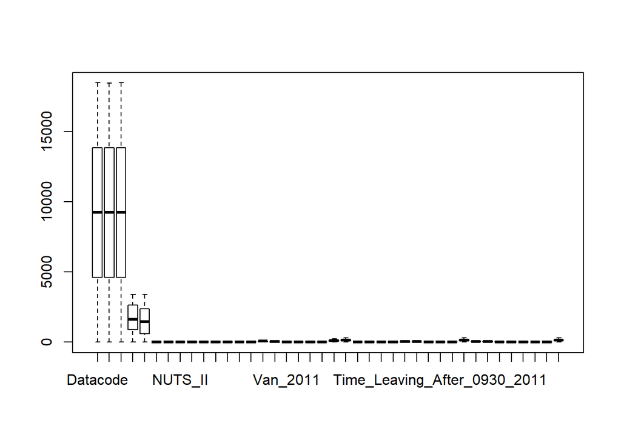

```r
boxplot(data, outline = FALSE)
```

```r
#Based on the summary stats for each column, we can decide a upper limit for values in each column
#In this way we can reduce the number of outliers
data <-
  subset(data, On_Foot_2011 < 50 &
      Bicycle_2011 < 10 &
      Bus_Minibus_Coach_2011 < 40 &
      Train_Dart_Luas_2011 < 10 &
      Motorcycle_Scooter_2011 < 5 &
      Car_Driver_2011 < 100 &
      Car_Passenger_2011 < 50 &
      Van_2011 < 20 &
      Other_2011 < 20 &
      Soft_Modes_Comb_2011 < 60 &
      Public_Transport_Comb_2011 < 50 &
      Private_Transport_Comb_2011 < 170 &
      Total_2011 < 300  &
      Time_Leaving_Before_0630_2011 < 20 &
      Time_Leaving_0630_0700_2011 < 30  &
      Time_Leaving_0701_0730_2011 < 30 &
      Time_Leaving_0731_8000_2011 < 50  &
      Time_Leaving_0801_0830_2011 < 50 &
      Time_Leaving_0831_0900_2011 < 60 &
      Time_Leaving_0901_0930_2011 < 30  &
      Time_Leaving_After_0930_2011 < 30 &
      Time_Leaving_Not_Stated_2011 < 15 &
      Time_Leaving_Total_2011 < 250 &
      Journey_Time_Under_15_mins_2011 < 100 &
      Journey_Time_Quarter_To_Under_Half_Hour_2011 < 75 &
      Journey_Time_Half_Hour_To_Under_Three_Quarter_Hours_2011 < 50 &
      Journey_Time_Three_Quarter_Hours_To_Under_One_Hour_2011 < 30  &
      Journey_Time_One_Hour_To_Under_One_Hour_Thirty_Mins_2011 < 20 &
      Journey_Time_One_And_Half_Hours_And_Over_2011 < 10 &
      Journey_Time_Not_Stated_2011 < 20 &
      Journey_Time_Total_2011 < 250
  )
```

## Erroneous Value Treatment

An entry in Planning.Region column is named South which should be Southern.

```r
print(unique(data$Planning.Region))
```

```
## [1] Southern             South                North and West
## [4]                      Eastern and Midlands
## Levels:  Eastern and Midlands North and West South Southern
```

```r
data$Planning.Region[data$Planning.Region == "South"] <- "Southern"
print(unique(data$Planning.Region))
```

```
## [1] Southern             North and West
## [4] Eastern and Midlands
## Levels:  Eastern and Midlands North and West South Southern
```

## Question 1

Question 1. What is the most popular mode of transport nationally?

Solution - To find out most popular transport mode nationally, we find average number of commuters for each mode and then find the mode that has maximum average.

```r
mean_transport_mode <- list()
index <- 10
for(i in 1:10){
  mean_transport_mode[i] <- mean(data[,index])
  index <- index + 1
}
mean_transport_mode
```

```
## [[1]]
## [1] 16.43463
##
## [[2]]
## [1] 1.625781
##
## [[3]]
## [1] 11.26627
##
## [[4]]
## [1] 0.8959686
##
## [[5]]
## [1] 0.2857493
##
## [[6]]
## [1] 46.77343
##
## [[7]]
## [1] 19.94731
##
## [[8]]
## [1] 5.658375
##
## [[9]]
## [1] 8.142017
##
## [[10]]
## [1] 18.06041
```

```r
#Most popular transport mode is the one with maximum mean
max_mode <- max(unlist(mean_transport_mode))
print(max_mode)
```

```
## [1] 46.77343
```

```r
for(i in 10:20){
  if (mean(data[,i]) == max_mode)
  print(str_c('The most popular mode of transport in Ireland is ', names(data[i])))
}
```

```
## [1] "The most popular mode of transport in Ireland is Car_Driver_2011"
```

## Question 2

Question 2. How does this (Answer to Q1) compare to the most popular mode of transport in your assigned county?

Solution - To find out most popular transport mode in the assigned county i.e. Donegal, we can make a new dataframe data2 with data related to only the assigned county and repeat the process as previous question.

```r
data2 <- filter(data, data$County == 'Donegal')    #Filter data related to Donegal only

mean_trans_mode_Donegal <- list()
index <- 10
for(i in 1:10){
  mean_trans_mode_Donegal[i] <- mean(data2[,index])
  index <- index + 1
}
print(mean_trans_mode_Donegal)
```

```
## [[1]]
## [1] 9.139265
##
## [[2]]
## [1] 0.3965184
##
## [[3]]
## [1] 14.34429
##
## [[4]]
## [1] 0.1276596
##
## [[5]]
## [1] 0.09284333
##
## [[6]]
## [1] 38.33462
##
## [[7]]
## [1] 19.17602
##
## [[8]]
## [1] 6.408124
##
## [[9]]
## [1] 7.537718
##
## [[10]]
## [1] 9.535783
```

```r
max_mode_Donegal <- max(unlist(mean_trans_mode_Donegal))
print(max_mode_Donegal)
```

```
## [1] 38.33462
```

```r
#Most popular transport mode is the one with maximum mean
for(i in 10:20){
  if (mean(data2[,i]) == max_mode_Donegal)
    print(str_c('The most popular mode of transport in Donegal is ', names(data2[i])))
}
```

```
## [1] "The most popular mode of transport in Donegal is Car_Driver_2011"
```

## Question 3

Question 3. What differences are evident between the choice of transportation in the cities compared to the other regions?

Solution - In order to differentiate between choice of transportation between cities and other regions, we divided the data into two dataframes data_cities and data_other, first for cities and second for other regions.Then, we calculate the mean number of commuters for each mode of transport for both the dataframes and generate bar plot for them.

```r
#For cities
data_cities = data %>% filter(grepl("City",data$County)) %>% summarise_all(funs(mean))
```

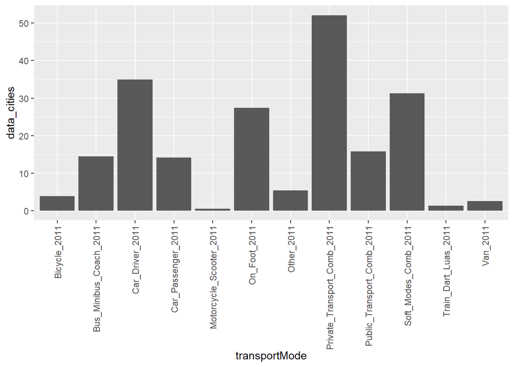

```r
data_cities = t(data_cities[10:21])
data_cities = data.frame(data_cities)
data_cities <- cbind(transportMode = rownames(data_cities), data_cities)

#Plot for transport mode in cities
ggplot(data=data_cities, aes(x=transportMode, y=data_cities)) +
  geom_bar(stat="identity") + theme(axis.text.x=element_text(angle=90,hjust=1,vjust=0.5))
```

```r
#For other regions
data_other = data %>% filter(!grepl("City",data$County)) %>% summarise_all(funs(mean))
```

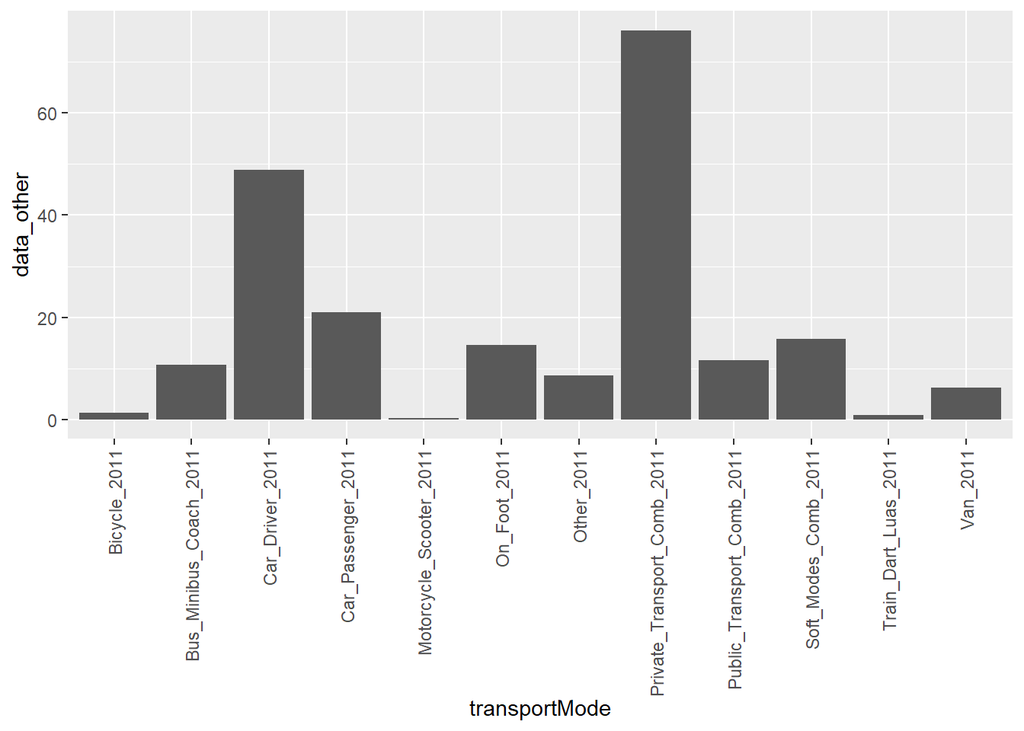

```r
data_other = t(data_other[10:21])
data_other = data.frame(data_other)
data_other <- cbind(transportMode = rownames(data_other), data_other)

#Plot for transport modes in other regions
ggplot(data=data_other, aes(x=transportMode, y=data_other)) +
  geom_bar(stat="identity") + theme(axis.text.x=element_text(angle=90,hjust=1,vjust=0.5))
```

## Question 4

Question 4. What proportion of commuters leave home outside of the 8-9am rush hour?

Solution - First calculate the total number of commuters that leave home home for work, school or college. Then calculate the number of commuters that leave outside 8-9 am rush hour by subtracting the the number of commuters between 8-9 am from total number of commuters. Finally, we calculate the proportion of commuters that travel outside the rush hour.

```r
totalCommuter <- sum(data[,"Time_Leaving_Total_2011"])
print(totalCommuter)
```

```
## [1] 874647
```

```r
commuter_OutRush <- totalCommuter - sum(sum(data[,"Time_Leaving_0801_0830_2011"]),
                                        sum(data[,"Time_Leaving_0831_0900_2011"]))

print(commuter_OutRush)
```

```
## [1] 488631
```

```r
prop <- commuter_OutRush/totalCommuter
print(str_c("Proportion of commuters leaving outside 8-9am is ", round(prop,2)))
```

```
## [1] "Proportion of commuters leaving outside 8-9am is 0.56"
```

## Question 5

Question 5. Are commuters in your assigned county likely to travel for longer than 45 minutes each morning?

Solution - First we calculate total number of commuters in Donegal which is the assigned county. Then we calculate the number of commuters who travel more than 45 minutes by adding up number of commuters who travel between three quarters to one hour, one hour to one hour thirty minutes and one hour thirty minutes and over. Then we calculate the ratio of commuters who travel more than 45 minutes to the total number of commuters.

```r
totalCommuterDonegal <- sum(data2[,"Journey_Time_Total_2011"])
print(str_c("Total number of people who commute in Donegal are ", totalCommuterDonegal))
```

```
## [1] "Total number of people who commute in Donegal are 47662"
```

```r
comm_more_than_45 <- sum(sum(data2[,"Journey_Time_Three_Quarter_Hours_To_Under_One_Hour_2011"]),
                         sum(data2[,"Journey_Time_One_Hour_To_Under_One_Hour_Thirty_Mins_2011"]),
                         sum(data2[,"Journey_Time_One_And_Half_Hours_And_Over_2011"]))
print(str_c("Total number of people in Donegal who travel for more than 45 minutes are ", comm_more_than_45))
```

```
## [1] "Total number of people in Donegal who travel for more than 45 minutes are 4450"
```

```r
prop_exceed_45 <- comm_more_than_45/totalCommuterDonegal
print(str_c("The proportion of people in Donegal who travel longer than 45 minutes is ",
            round(prop_exceed_45, 3), " which is quite less."))
```

```
## [1] "The proportion of people in Donegal who travel longer than 45 minutes is 0.093 which is quite less."
```

## Question 6

Question 6. How does this (Answer to Q5) compare to other counties in the same NUTS III region?

Solution - First we determine the NUTSIII region for the assigned county (Donegal) which comes out to be Border. Then we create a new dataframe data3, which contains the data only for Border region. Now, we repeat the steps of previous solution for each county in Border region.

```r
nut <- data2$NUTS_III[1]          #To determine NUTSIII region for assigned county (Donegal)
data3 <- filter(data, data$NUTS_III == nut)   #Filter data for Border NUTSIII region
counties <- data3 %>% distinct(County)

totalCommuterNut <- list()       #List for total number of commuters

for(u in 1:6){
  totalCommuterNut[u] <- sum(filter(data3, data3$County == counties[u,])[,"Journey_Time_Total_2011"])
}
totalCommuterNut
```

```
## [[1]]
## [1] 19408
##
## [[2]]
## [1] 47662
##
## [[3]]
## [1] 12630
##
## [[4]]
## [1] 24372
##
## [[5]]
## [1] 14604
##
## [[6]]
## [1] 18419
```

```r
commuterExceed_Nut <- list()       #List for commuters who exceed 45 min
for(county in 1:6){
  commuterExceed_Nut[county] <- sum(sum(filter(data3, data3$County == counties[county,])[,"Journey_Time_Three_Quarter_Hours_To_Under_One_Hour_2011"]),
                       sum(filter(data3, data3$County == counties[county,])[,"Journey_Time_One_Hour_To_Under_One_Hour_Thirty_Mins_2011"]),
                       sum(filter(data3, data3$County == counties[county,])[,"Journey_Time_One_And_Half_Hours_And_Over_2011"]))
}
commuterExceed_Nut
```

```
## [[1]]
## [1] 2287
##
## [[2]]
## [1] 4450
##
## [[3]]
## [1] 1418
##
## [[4]]
## [1] 3082
##
## [[5]]
## [1] 1441
##
## [[6]]
## [1] 1453
```

```r
propExceedNut <- list()
for(n in 1:6){
  propExceedNut <- unlist(commuterExceed_Nut[n])/unlist(totalCommuterNut[n])
  print(str_c("Proportion of commuters who travel for more than 45 minutes in ", counties[n,], " is ",
              round(propExceedNut, 3)))
}
```

```
## [1] "Proportion of commuters who travel for more than 45 minutes in Cavan is 0.118"
## [1] "Proportion of commuters who travel for more than 45 minutes in Donegal is 0.093"
## [1] "Proportion of commuters who travel for more than 45 minutes in Leitrim is 0.112"
## [1] "Proportion of commuters who travel for more than 45 minutes in Louth is 0.126"
## [1] "Proportion of commuters who travel for more than 45 minutes in Monaghan is 0.099"
## [1] "Proportion of commuters who travel for more than 45 minutes in Sligo is 0.079"
```

## Question 7

Question 7. The residents of which five counties experience the longest commute times?

Solution - First we calculate the total number of commuters who travel for more that one hour thirty minutes in each county and categorise them county-wise. Then we arrange this data in ascending order and select bottom 5 rows which gives us 5 largest values for commuter count. Next, we compare these counts with count for each county and successful matches gives us the names of those 5 counties where commuters experience longest commute time.

```r
data_by_county <- data %>% group_by(County) %>% summarise(sum(Journey_Time_One_And_Half_Hours_And_Over_2011))
colnames(data_by_county)[2] <- "Journey_Time_One_And_Half_Hours_And_Over_2011"

top5 <- tail(sort(data_by_county$Journey_Time_One_And_Half_Hours_And_Over_2011),5)

print("The below five Counties experience the longest commute time")
```

```
## [1] "The below five Counties experience the longest commute time"
```

```r
for(i in 1:33){
  for(j in 1:5){
    if(data_by_county$Journey_Time_One_And_Half_Hours_And_Over_2011[i]==top5[j]){
      print(as.character(data_by_county$County[i]))
    }
  }
}
```

```
## [1] "Cork County"
## [1] "Galway County"
## [1] "Kildare"
## [1] "Meath"
## [1] "Wexford"
```

## Question 8

Question 8. What proportion of cars used in the morning commute contain only one person?

Solution - First we calculate the total number of car users by combining the columns Car_Driver_2011 and Car_Passenger_2011. Then, we find out the total number of cars where number of passanger is only 1. Finally we calculate the ration of number of cars with one passanger to total number of cars.

```r
carUser_Total <- data %>% transmute(data$Car_Driver_2011 + data$Car_Passenger_2011)
colnames(carUser_Total)[1] <- "Total Car Users"

one_person_car <- sum(nrow(subset(data,data$Car_Passenger_2011 == 1)),
                    nrow(subset(data,data$Car_Driver_2011 == 1)))

one_person_car_proportion <- one_person_car/sum(carUser_Total)

print(str_c("The proportion of cars used in the morning commute that contains only one person is ",
      one_person_car_proportion))
```

```
## [1] "The proportion of cars used in the morning commute that contains only one person is 0.000200180713598331"
```

## Question 10

Question 10. Which Electoral Division within each Planning Region do you propose should be prioritised for investment in public transportation?

Solution - First we determine all the distinct planning regions. Then, within each planning region we calculate the number of public transport users and number of total users for each electoral division. Then we calculate the proportion of number of commuters using public transport to total number of commuters for each electoral division. The electoral division with lowest proportion is the one where we should prioritise investment.

```r
PlanningRegionList <- data %>% distinct(Planning.Region)
PlanningRegionList <- PlanningRegionList[!apply(PlanningRegionList == "", 1, all),]
PlanningRegionList
```

```
## [1] Southern             North and West       Eastern and Midlands
## Levels:  Eastern and Midlands North and West South Southern
```

```r
for(x in 1:3) {
  sum_public_transport = data %>%
    filter(Planning.Region == PlanningRegionList[x]) %>%
    group_by(Electoral.Division.Name) %>%
    summarise(sum(Public_Transport_Comb_2011))

  sum_total = data %>% filter(Planning.Region == PlanningRegionList[x]) %>%
    group_by(Electoral.Division.Name)  %>%
    summarise(sum(Total_2011))
  public_proportion = sum_public_transport$`sum(Public_Transport_Comb_2011)`/sum_total$`sum(Total_2011)`

  print(str_c("For Planning Region ",PlanningRegionList[x],
              ", it is proposed to invest in public transportation in ",
              sum_public_transport$Electoral.Division.Name[which.min(public_proportion)],
              " since the proportion of public transport is ", round(min(public_proportion),2),
              " which is least within this planning region"))
}
```

```
## [1] "For Planning Region Southern, it is proposed to invest in public transportation in 138 Ballyblood since the proportion of public transport is 0 which is least within this planning region"
## [1] "For Planning Region North and West, it is proposed to invest in public transportation in 090 Fuerty since the proportion of public transport is 0.01 which is least within this planning region"
## [1] "For Planning Region Eastern and Midlands, it is proposed to invest in public transportation in 027 Granard Urban since the proportion of public transport is 0.01 which is least within this planning region"
```

## Reflection on the Assignment

Overall, the project was an exciting and challenging assignment which demanded good command over string and data manipulation libraries such as stringr and dplyr as well as visualisation library like ggplot2.

It was observed that majority of the people prefer cars and other private modes of transportation for commuting from home to work, school or college compared to other public transportation modes.